# Cryptocurrency trends analyzer: platform for portfolio analysis and hedging

10 august 2017

# Introductiion

It is well know that the recording of price of assets over time form into variables that are denoted as time series. The analysis of time series dates back to 1940s and is well established field in econometrics. Definitely one of the most distinguished paper in this stream is an article of Prof. Johansen from 1988, (Johansen 1988), which has defined the development of the discipline for the next $30$ years. This article shows how to test the exact form of dependency across a set of time series corresponding each to another economic variable. In a nutshell this philosophy assumes that there are some common trends which drive the evolution of time series and based of the methodology developed by Prof. Johansen, we are able to identify those trends. It is natural that from statistical point of view those trends are nothing else as time series themselves.

The field that tackles the analysis of common trends among many time series is called cointegration analysis. In the early ppaers of $1980$s and $1990$s, the cointegration analysis has mostly been applied to analysis of macroeconomic time series, which describe main indicators of economy in a macroscale. With deeper and deeper understanding of financial markets dynamics, the cointegration analysis has been applied also to modeling of asset prices and their linkages. That was somehow natural as asset prices are modeled as random walks, simple, but very general processes that ensemble the idea of randomness over time. In a nutshell we can think about a random walk as a process which, starting at some level, can grow or decrease by one unit every period with the probability weights associated with an increase and decrease. Typically, for theoretical analysis it is assumed that those probabilites equal $0.5$ for both the increase and decrease. In fact, it is more likely that in case of financial markets those probabilities may fluctuate, what brings an important aspect of market trending and momentum strategy (following the trend) as a direct application field for the cointegration analysis as well.

The use of cointegration for analyzing financial data is well established over the last $20$ years. Regarding the most influential papers in the discipline, the problem of price discovery is discussed by (Hasbrouck 1988), (Lehmann 2002), (Jong and Schotman 2010), and (Grammig and Schlag 2005). Gatev, Goetzmann, and Rouwe (2006) study pairs trading, and continuous time models with a heteroscedastic error process are developed by Duan and Pliska (2004) and Nakajima and Ohashi (2011). Alexander (1999), and more recently Juhl, Kawaller, and Koch (2012), studied optimal hedging using cointegration. Finally (Johansen and Gatarek 2017) have developed a methodology for optimal portfolio construction based on asset prices driven by random walks with portfolio weights depending on the hedging horizon.

To sum up, there are a few key building blocks that the methodology is based upon. First of all we assume that the cryptocurrency rate as any other exchange rate or financial asset price can be modeled with a random walk. Second we assume that there is a probability distribution that stands behind this random walk, in terms of up - and downmovement. Then, it is assumed that the evolution of this probability over time can lead to periods of rising trends and downturns. Furthermore, we assume that the historical quotations of the cryptocurrency rate can be explored for estimating on the relation between the price movements and the probability distribution governing the random walk behind. Finally we assume that the entire spectrum of price series which are representing the cryptocurrencies can be modeled by means of cointegration analysis and as it is the case we have the entire spectrum of methods developed by econometrics available for portfolio construction in such a market.

What we can offer based on this methodology? In the end effect we are going to combine a few advanced statistical components into one cohererent system. The probability filtering model will be the main building block of the system. Based on this model the customer obtains signal which present current market sentiment in the market: upward or downward trend with information on the exact timing of the start of such a trend and current posisiton of the system (cryptocurrency price) with respect to the extent of the trend. Initial analysis show that the trends are definitely alternating in the sense that the succession of donwward movements and upward trends ensmble the shape of trigonometric series. The system is expected to deliver the expected time of arrival at the equilibrium which is interpreted as an end of the trend. In that sense the equilibrium is interpreted as a phase when market takes no direction or is just after an end of a trend. Such analysis allows for momentum trading based on the identified trend and presents a possibility for trend following. That elemtn of the system is accurate enough for outright transactions.

Apart from the signaling functionality, which is the key component of the system, the platform allows for portfolio construction around a selected cryptocurrency. For example if a customer selects a cryptocurrency that is in the upward trend and wishes to enter a long position in this cryptocurrency, she can hedge this position with a portfolio around it. To that end the methodology in (Johansen and Gatarek 2017) is applied. The fact that cryptocurrencies can be modeled by means of random walks, which are definitely driven by common trends, and the fact that they are characterized by extensive amount of correlation among each other, opens a wide application potential for methods developed in (Johansen and Gatarek 2017). The methodology assumes that the assets can be modeled with a cointegration model. Given the selected cryptocurrency to be traded, the system selects the optimal set of variables to enter the cointegration model. This set is selected among all the other cryptocurrencies analyzed by the platform. Given that the model is estimated, methodology developed in (Johansen and Gatarek 2017) is applied to deliver the optimal portfolio weights to deliver a minimum portfolio variance in an assumed horizon. This horizon is also indicated by the model based on the time series properties of the evolution of the probability which has been discussed above. The initial analysis indicates that the first derivative of the probability curve indicates highly cyclic behaviour. The expected length of the cycle can be computed from the past data based on time series techniques. Of course, the customer can define the horizon in an ad hoc fashion and select corresponding portfolio instead of the one inidicated by the cycle model.

# Motivation: fluctuations in the coin tossing

The idea of the methodology we put forward stem from the theory of random walk fluctuations. This theory has been put forward in the middle of twentieth century and has been very appealing at that time and so it remains today. the results concerning fluctuations in coin tossing show that widely held beliefs about the law of large numbers are fallacious. They are so amazing and so at variance with common intuition that even sophisticated professors of statistics have longed doubted that coins actually misbehave as standard theory of random walk predicts. This theory has been developed addressing the coin tossing but the results are representative of a fairly general situation that can be described in form of a random path in two dimensional space of time and value (of an asset in tis case). In this paper we present the part of the thoery of random walk fluctuations which is necessary for understanding the main idea of methodolgy we are about to develop. We are motivated principally by the unexpected discovery that this theory can be treated by elemantary method of mathematics, in particular basic combinatorics and fairly basic statistical theory.

We start with defining the descrining the typical coin-tossing game and its relation to the simple random walk. Lets imagine there is some initial fortune equal to zero at the beginning of the game. Every period (it can be a second, day, month etc.) we toss a fair coin, each time either collecting 1 unit of value (can be 1 usd for instance) from our opponent or paying it out. By the Law of Large Numbers, as the number of games played increases, the fraction of games with positive outcome approaches 1/2. In the course of the game, however, our fortune is likely to fluctuate, changing sign from positive to negative and back, so the question which may be asked is the following one: after a large number $n$ of games have been played, what is the fraction of time when the total wealth remained in the winning zone?

By the obvious symmetry, in the time between the consequitive draws, when the total wealth becomes zero, the fortune is equally likely to stay in the positive and negative area. As more games are played, more draws will occur, which seem to imply that the fraction of time spent in positive area goes to $1/2$. This would be standard intuition put forward by everyman asked the above mentioned question. In fact this intuition is completely wrong! The fraction of time to be spent in positive area is more likely to be close to extremities $0$ or $1$ than to be close to $1/2$.

To understand this phenomena we need to take a closer look at the nature of chance fluctuations in random walks. the results are startling. As mentioned above, according to the widespread belief a so-called law of averages should ensure that in a long coin-tossing game each player will be on the winning and losing side for about half the time, and that the lead will pass not infrequently from one player to another one. Lets imagine then a huge sample of records of ideal coin-tossing games, each consisting of $2n$ trials. We pick one at random and identify the period of last draw, where the number of accumulated heads and tails were equal. This number is even, and we denote it by $2k$ (so that $0<k<n$). Frequent changes of the lead would imply that $k$ is likely to be relaitvely close to $n$, but in practice this is not so. In fact, the distribution of $k$ is symmetric (any value of $k$ has exactly the same probability as the value of $n-k$). Furthermore, the probabilities near the end points are greatest. The most possible values for $k$ are the extremes of $0$ and $n$. The intuition lead to an erroneous picture of probable effects of coin fluctuations. Figure $1$ demonstrates the typical probability denisty function for variable $k/n$. see

The understand the relation of point where random walk cross a zero line, period $k$ and its relation to the total length of the path, we need to take a closer look at the nature of the problem. Let us assume that we work with the simplest possible definition of random walk, which is defines as a process which starts at period $0$ with value $0$ and spans over $2n$ periods, and each period it can increase or decrease in value by $1$ unit. From a formal point of view we shall be concerned with arrangment of $2n$ plus ones and minus ones. If we refer to $2n$ as the length of the random walk path, then there are $2^{2n}$ different possible paths which can realize with this length of the process. Why? Because each period, called alternatively as an epoch $k=1,\ldots,n$, the process have two options to evolve: either $+1$ or $-1$. Then in two consequtive periods it has $2x2$ options to evolve, and in $2n$ periods, it can evolve in $\underbrace{2\times 2 \times 2\ldots 2}_\text{2n}$ different ways.

If we restrict the paths somehow, the number of potential trajectories goes down immediately. For instance lets imagine that we assume that among the $2n$ epochs we observe $p$ plus ones and $q$ minus ones. Then, naturally $2n = p + q$ and the value at the period $2n$, so the termina value of all such paths equals $p\times 1 + q \times (-1) = p-q$. Let us denote the latter with $x$. Then a path from origin to an arbitrary point $(2n, x)$ exists if and only if $2n$ and $x$ remain in the abovementioned relation to $p$ and $q$. Thus each point $(2n, x)$ automatically implies the corresponding values of $p$ and $q$.

For instance let us imagine we are interested in the random walk paths that connect the origin $(0,0)$ with the point $(6,2)$. Then, according to the formulas we need to solve the system.
$$6 = p + q\\
2 = p - q$$
which is satisfied by $p=4$ and $q=2$. That means nothing more than the all the paths which lead the process to the value of $2$ in $6$ steps result from $4$ plus ones and $2$ minus ones. The immediate question that arrives: how many paths of that sort can be constructed? The answer to that question is fairly simple: that is a number of ways we can distribute $4$ balls with a ticker plus ones in $6$ bins. Thus the anser is:
$${6}\choose{4}$$
which generalize to

\begin{equation}\label{2np} {2n}\choose{p}. \end{equation} Importantly
$${{2n}\choose{p}} = {{2n}\choose{q}}.$$
In this chapter we are mostly devoted to the paths which revert to a zero at some point of time, so where a draw occurs at some point. A piece of random walk path between zeroes (draws) is called an excursion from zero. Let us denote bu $u_{2n}$ the probability of a return to zero at period $2n$
$$u_{2n} = P(S_{2n} = 0)$$
where $S$ denotes a path of random walk ($S$ stems from the fact that we define the random walk as a sum of a sequence of plus and minus ones). Given the probability we have derived in we can compute the $u_{2n}$ as \begin{equation}\label{u2n} u_{2n} = {{2n} \choose {n}} 2^{-2n}. \end{equation}

The first term ${2n} \choose {n}$ is motivated by the fact that $n$ out of $2n$ plus ones must occur on the path so that it reverts back to $0$ in $2n$ periods. That means that $p=n$ in . The term $2^{-2}$ is nothing else as a total number of all the possible paths between $0$ and $2n$. The important theorem that we base upon is well known from the theory of random walk. It states what follows.

The probability that up to and including period $2n$ the random walk visits the positive area for $2k$ periods ($0<=2k<=2n$) and the negative one for $2n-2k$ periods is given by \begin{equation}\label{arcsinth} p_{2k,2n} = u_{2k} u_{2n-2k}. \end{equation}

According to the definition of $u_{2n}$ in \begin{equation}\label{p2k2nn} p_{2k,2n} = {{2k} \choose {k}} 2^{-2k} {{2(n-k)} \choose {n-k}} 2^{-2(n-k)} = {{2k} \choose {k}} {{2(n-k)} \choose {n-k}} 2^{-2n}. \end{equation}

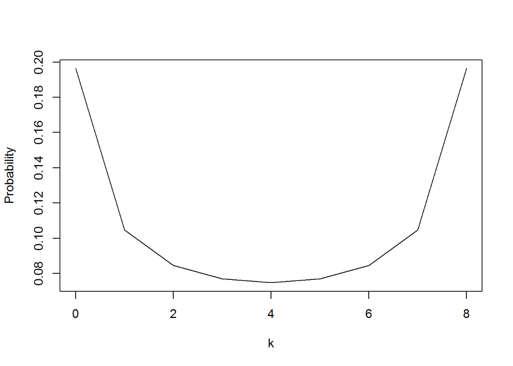

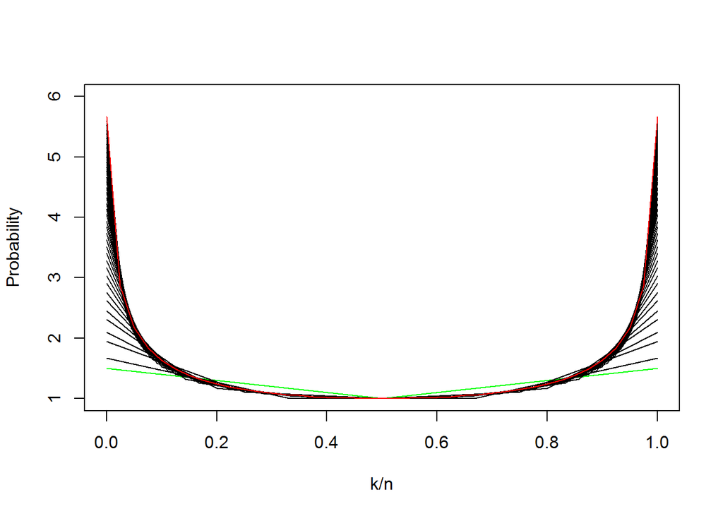

To present the full spectrum of results associated with the arc sine distribution we need to express the binomial coefficient in terms of factorials, according to Stirling’s formula. It can be shown that
$$u_{2n} = \frac{1}{\sqrt{pn}}$$
. Applying that formula to we obtain a result \begin{equation}\label{p2k2nnpdf} p_{2k,2n} = \frac{1}{\pi \sqrt(k)\sqrt(n-k)}. \end{equation} The latter one is in fact equivalent to \begin{equation} p_{2k,2n} = \frac{1}{n \pi \sqrt(k/n)\sqrt((n-k)/n)}. \end{equation} If we denote $x_k = \frac{k}{n}$ we can evaluate the last equation as \begin{equation} p_{2k,2n} = \frac{1}{n} f(x_k), \end{equation}

with $f(x) = \frac{1}{\pi\sqrt(x(1-x))}$. This function gives a shape shown below with its height varying depending of n.

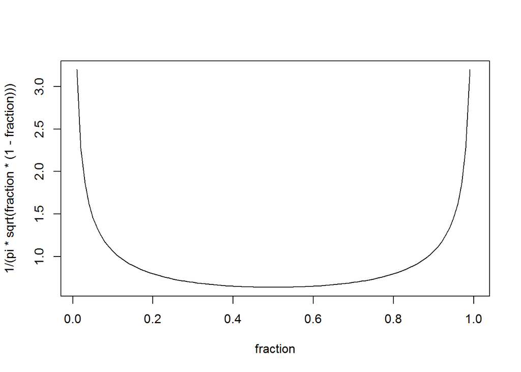

Now, let us iamgine that we need to compute the probability that fraction $k/n$ spends positive area for a period which is higher than $1/2$ and lower than some fraction $\alpha$, i.e. $1/2<\alpha<1$. Accroding to our derivation such a probability is given by \begin{equation} \sum_{n/2 < k < \alpha n} p_{2k,2n} = \frac{1}{\pi n} \sum_{ n/2 < k < \alpha n} \frac{1}{\big(\frac{k}{n}(1-\frac{k}{n})\big)^{1/2}}, \end{equation} which can be approximated by a Riemannian integral \begin{equation} \pi^{-1} \int_{1/2}^{\alpha} \frac{dx}{\big(x(1-x)\big)^{1/2}} = 2\pi^{-1} \arcsin \alpha^{1/2} -1/2 \end{equation} And because of the fact that \begin{equation} \pi^{-1} \int_{0}^{1/2} \frac{dx}{\big(x(1-x)\big)^{1/2}} = 1/2 \end{equation} we obtain \begin{equation} \pi^{-1} \int_{0}^{\alpha} \frac{dx}{\big(x(1-x)\big)^{1/2}} = 2\pi^{-1} \arcsin \alpha^{1/2}, \end{equation}

which is a cumulative distribution function of the arc sine distribution. The shape of this function is presented below. It is an immediate result from the shape of the fuction that the fraction of time spent in the positive area is much more likely to be close to zero or one, than to be close to the expected value of $1/2$

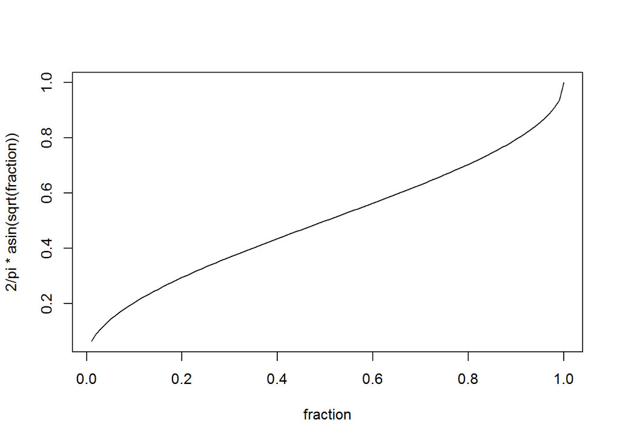

The cumulative distribution function is very useful when one needs to read the probability of a less fortunate player to win. Let us imagine the random walk ensembles two players who play a game. If a player A wins the random walk visits the positive area. If she loses, the negative area is visited.

Then from the cdf we can compute the probability that corresponds to the situation that a less fortunate player is going to win for a certain proportion of time. That proportion can be denoted by $X$, where $(X<1/2)$. Then \begin{equation} P_X = 2\pi^{-1} \arcsin X^{1/2}, \end{equation}

corresponds to the probability that the fraction of time that the less fortunate player has been in a winning position was smaller than $X$. As we work with a symmetic problem (each of two players can be less frotunate), we need to multiply $P_X$ by a factor of $2$. For instance if we take a fraction of of $10\%$, then the corresponding probability is given by $2 \times 2\pi^{-1} \arcsin 0.1^{1/2} = 0.4$. This means that we can state that there is $40\%$ probability that the less fortunate player would win in maximally $10\%$ of cases. What is more shocking corresponds to extreme levels of for instance $X=0.01$. Then $2 \times 2\pi^{-1} \arcsin 0.01^{1/2} = 0.13$. That value implies the $13\%$ probability that the less fortunate player would be winning not more than $1\%$ of cases. This result is striking.

We present a short simulation study that confirms the result of this theoretical result. We simulate $1000$ paths of random walks of length $100$, i.e. for each out of $100$ periods we sample either plus one or minus one, both with probability $1/2$. We do the same for $1000$ trajectories of the random walk. Then for each trajectory we count a number of periods the random walk has been observed in the positive trajectory. Those counts are recorded in a vector. Then we plot the cumulative distribution function of this vector (the green line in the plot). The theoretical analytical form of the respective arc sine cdf is plotted with a red line.

Now imagine we start perturbing the probability, in the sense that instead of the equal probability of occurrence of plus and minus ones set at $0.5$, we consider $10$ additional scenarios in each of them increasing the probability of plus one by $0.01$. Thus the probabilities of plus one in the alternative scenarios vary from $0.51$ to $0.6$. For each of those scenarios we repeat exactly the same experiment. We simulate $1000$ of random walks of length $100$ with a selected level of probability of plus one.

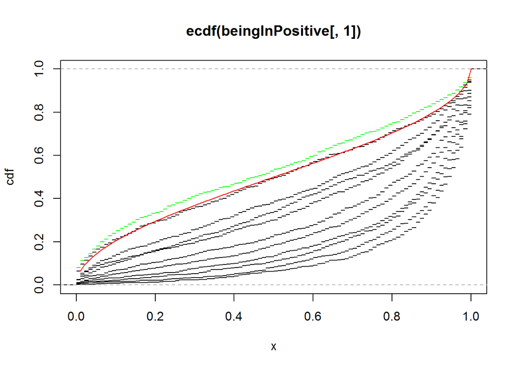

```r
# length of random walk
T <- 100
# number of simulations of random walk
nSim <- 1000

randomWalkRecordings <- matrix(NA, nSim, T)
# number of scenarios for probability of plus and minus ones
J <- 11
# beingInPositive is avariable indicating percentage of time that the random
# walk goes into the positive area
beingInPositive <- matrix(NA, nSim, J)
for (j in 1:J) {
    prob <- 0.5 + 1 * (j - 1)/100
    for (i in 1:nSim) {
        eps <- rbinom(T, 1, prob)
        eps[eps == 0] <- -1
        randomWalkRecordings[i, ] <- cumsum(eps)
        beingInPositive[i, j] <- sum(randomWalkRecordings[i, ] > 0)/T
    }
}
plot(ecdf(beingInPositive[, 1]), do.points = F, lty = 1, col = "green", xlim = c(0,
    1), ylab = "cdf")
for (j in 2:J) {
    lines(ecdf(beingInPositive[, j]), do.points = F)
}
p <- (1:100)/100
cdf <- 2/pi * asin(sqrt(p))
lines(p, cdf, col = "red", type = "l")
```

# Filtering of time series: estimation of probability evolution

The models applied in case of cryptocurrency modeling need to tackle an important aspect in the sense that inference must be made online, before the data collection ends. For those types of applications one must have, at any time, an up-to-date estimate of the current state of the system. By the state of the system, the current value of parameters is considered. In that case we estimate the probability of an price move from the currency price of the assets and as such we need to have the best possible current estimate of the probability. The density of the current estimate of the parameters is usually called the filtering density. Let us denote it by $p(\theta_t|y_{1:t})$. It denotes the best knowledge about the parameter $\theta_t$ that we have based on the information in the data up to the period $t$. This density can be restated as \begin{equation} p(\theta_t|y_t, y_{1:t-1}) = \frac{p(\theta_t, y_t| y_{1:t-1})}{p(y_t|y_{1:t-1})} \end{equation}

based on the definition of the conditional probability.

At the same time we can state \begin{equation} p(\theta_t, y_t| y_{1:t-1}) = p(y_t|\theta_t, y_{1:t-1}) p(\theta_t|y_{1:t-1}) = p(y_t|\theta_t) p(\theta_t|y_{1:t-1}), \end{equation} in which we recognize the likelihood $p(y_t|\theta_t)$ and the prior density $p(\theta_t|y_{1:t-1})$ which describes the prior knowledge about the state of the parameter $\theta_t$ before the new observation $y_t$ is recorded. By joining the equations together we can obtain exact form of the filtering density \begin{equation} p(\theta_t|y_t, y_{1:t-1}) = \frac{p(y_t|\theta_t) p(\theta_t|y_{1:t-1})}{p(y_t|y_{1:t-1})} \end{equation} The density $p(\theta_t|y_{1:t-1})$ can be described as a one-step-ahead predictive density for the states. Given that we know where the system was in the previous period, so that we know the density $p(\theta_{t-1}|y_{1:t-1})$, and given that we know the form of dependence of state of the parameter today as a function of the state of the parameter in the previous period $p(\theta_t|\theta_{t-1})$, we can derive \begin{equation} p(\theta_{t}|y_{1:t-1}) = \int p(\theta_{t}, \theta_{t-1}|y_{1:t-1}) d \theta_{t-1} = \int p(\theta_{t}| \theta_{t-1}, y_{1:t-1}) p(\theta_{t-1}|y_{1:t-1}) d \theta_{t-1} = \int p(\theta_{t}| \theta_{t-1}) p(\theta_{t-1}|y_{1:t-1}) d \theta_{t-1} \end{equation}

http://mathworld.wolfram.com/RandomWalk1-Dimensional.html

# Portfolio construction

The main goal of the discussion above was to understand the idea that the evolution of the probability curve for cryptocurrencies analyzed by the system allows for selection of cryptocurrency with the expected behavior: rising or declining trend. As soon as that step has been accomplished, the investor has two options: either to invest in this cryptocurrency in an outright manner (creating a portfolio consisiting only of this cryptocurrency), or investing in a wider portfolio, consisting also of cryptocurrencies, which constitute a proper hedge for the underlying crptocurrency.

Consider the situation that an investor enters an unhedged, outright position. She is worried about the risk due to changing prices which might developed in an unpredictable manner due to the idiosyncratic shocks which are definitely observed in the market and add on substantially to the risk of this investment. To mitigate this risk the investor decides to hedge by short selling other cryptocurrencies which are correlated with the underlying cryptocurrecny. (Johansen and Gatarek 2017) has shown that to properly hedge the assets which developes as random walks evolving accrodingly to some common trends, the investor is better off is she hedges with assets which are not only correlated but also cointegrated with the underlying. The problem is which amounts, the hedge ratios, the hedging cryptocurrencies should be bought/sold to hedge optimally the risk due to the variation of the prices, as measured by conditional variance. Note that instead of holding the first asset, we are buying it and short seeling the hedging assets. In case of a short position in the underlying asset (i.e. when the trend is declining), we are short selling the undelying asset and buying the hedges according to the hedge ratios.

## Cointegration modeling

Before we skizz the methodology of (Johansen and Gatarek 2017) which constitute a basis for the portfolio construction part of the platform, we shortly explain the idea behind the cointegration model, which is a necessary element on the way to compute the hedge ratios.

The cointegrated vector autoregressive model (CVAR) is assumed to describe the variation of the cryptocurrency prices. This model allows for nonstationary prices (random walk, which have nonstationary behaviour) with stationary linear combinations, that is cointegration. Cointegration models time series which follow common trends. Linear combination of individual time series is nothing more as a common trend which is followed by the individual prices with a different strentgh. Some of the first attempts to model common trends with cointegration can be found in (Kasa 1992). Since then, cointegration has been found and tested for in many financial markets.

The cointegration approach to trading in financial markets has been implemented in many important studies studies, for instance, (Lin, McCrae, and Gulati 2006), (Vidyamurthy 2004), (Gillespie and Ulph 2001), (Alexander and Dimitriu 2005a), (Alexander and Dimitriu 2005b) and (Gutierrez and Tse 2011). Recently, researchers, who are part of the project group have published a paper, see (Ardia and Van Dijk 2016) which shows important theoretical development necessary for succesfull application of cointegration to financial market analysis. Those techniques are directly applicable to the case of cryptocurrencies and will be part of the engine behind the platform.

```r
source("commonTrends.R")
```

The outcome of cointegration modeling is a set of parameters which defines the number of common trends driving the system of time series. Those parameters are necessary for implementing hedging methodology presented in (Johansen and Gatarek 2017).

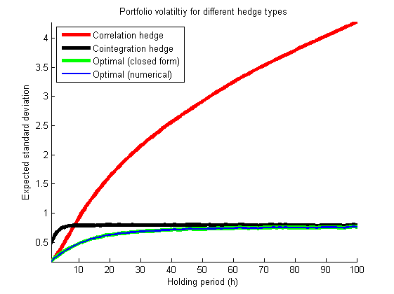

In general, the hedging methods can be divided in two classes: static and dynamic methods. The static hedging techniques assume that the hedging portfolio is selected, given information available in period $t$, and remains unchanged during the entire holding period $t+1,\ldots,t+h$. This is opposed to the dynamic hedging methods which allows for rebalancing the portfolio during the holding period, but we are only concerned with static hedging.

The first set of results concerns the derivation of an expression for the risk, $\Sigma_{t,h},$ which depends on conditional volatility of the error term. Based on this expression, the optimal $h-$period hedging portfolio, which minimizes this risk is derived. The limit for $h\rightarrow\infty$ of the inverse risk matrix, $\Sigma_{t,h}^{-1},$ is found and used to show that the optimal portfolio approaches a variance minimal cointegrating portfolio, which has a bounded risk.

Thus for longer horizons we should choose the variance minimal cointegrating portfolio, which has a bounded risk, and for shorter horizons we should take conditional volatility into account.

The second set of results concerns estimation of risk, and the optimal $h$-period hedging portfolio based on data $y_{t},t=1,\dots,T$. Under assumptions on the error term that allows for heteroscedasticity, we show two results. First we show that a regression of returns $y_{t+h}-y_{t}$ on information at time $t$ gives a consistent estimator for $\Sigma_{h},$ and a similar result holds if the CVAR is estimated by reduced rank regression. Next it is shown that a regression of $y_{1t}$ on the other prices and a constant gives a consistent estimator of the optimal limiting hedging portfolio.

The conclusion of this is, that if the conditional variance is used as risk measure, in the case of conditional volatility, this has to be modelled by a multivariate GARCH model, like the BEKK model, see for instance Engle and Kroner (1995) and Comte and Lieberman (2003), or a multivariate ARCH model like Li, Ling, and Wong (2001). The combined theory of cointegration and a model for heteroscedasticity is challenging. The obvious two-step procedure of first estimating the CVAR assuming i.i.d. Gaussian errors and then use the estimated residuals as input in a BEKK model has not been work out in details.

The well-known formula
$$Var(y_{t+h}-y_{t})=E(Var_{t}(y_{t+h}-y_{t}))+Var(E_{t}(y_{t+h}-y_{t})),$$
shows that the choice between the conditional variance, $\Sigma_{h,t}$ and its expectation, $\Sigma_{h},$ does not involve the variation of the information $y_{t}$ given at the time of investment.

If a consistent estimator of $\Sigma_{t,h}=Var_{t}(y_{t+h}-y_{t})$ is needed, one has to model conditional volatility, but if the first term $\Sigma _{h}=E(Var_{t}(y_{t+h}-y_{t}))$ can be used, it can be estimated by the simple regression methods or from the CVAR.

The role of cointegration for hedging was analysed by Juhl, Kawaller, and Koch (2011). They considered a special case of the CVAR, and we want in this paper to generalize their results to a CVAR with more lags and more cointegrating relations and allow for a some degree of heteroscedasticity in the martingale error term.

We conclude that cointegration plays an important role in hedging. It allows for the possibility that an $h$-period hedging portfolio has a risk that is bounded in the horizon $h$, as opposed to the unhedged risk. As important is the result that for moderate horizons, it is important not to use the cointegrating portfolio, but to use the optimal hedging portfolio which interpolates between the short and long-horizon cointegrating portfolio.

# References

Alexander, C., and A. Dimitriu. 2005a. “Indexing and Statistical Arbitrage: Tracking Error or Cointegration?” *Journal of Portfolio Management* 31: 50–63.

———. 2005b. “Indexing, Cointegration and Equity Market Regimes.” *International Journal of Finance and Economics* 10: 213–31.

Ardia, Gatarek, D., and H.K. Van Dijk. 2016. “Return and Risk of Pairs Trading Using a Simulation-Based Bayesian Procedure for Predicting Stable Ratios of Stock Prices.” *Econometrics* 4 (1).

Gillespie, T., and C. Ulph. 2001. “Pair Trades Methodology: A Question of Mean Reversion.” Proceedings of International Conference on Statistics, Combinatorics and Related Areas and the 8th International Conference of Forum for Interdisciplinary Mathematics, NSW.

Grammig, Melvin, J., and C. Schlag. 2005. “Internationally cross-listed stock prices during overlapping trading hours: price discovery and exchange rate effects.” *Journal of Financial Econometrics* 12: 139–64.

Gutierrez, J. A., and Y. Tse. 2011. “Illuminating the Profitability of Pairs Trading: A Test of the Relative Pricing Efficiency of Markets for Water Utility Stocks.” *The Journal of Trading* 6 (2): 50–64.

Hasbrouck, J. 1988. “One security, many markets: determining the contributions to price discovery.” *The Journal of Finance* 50: 1175–99.

Johansen, S. 1988. “Statistical analysis of cointegration vectors.” *Journal of Economic Dynamics and Control* 12: 231–54.

Johansen, S., and L. Gatarek. 2017. “The Role of Cointegration for Optimal Hedging with Heteroscedastic Error Term.” *Journal of Econometrics* final revision. http://pure.au.dk/portal/en/publications/id(c0d43f7f-8cba-45fe-b554-f0b716c4d389).html.

Jong, F. de, and P.C. Schotman. 2010. “Price discovery in fragmented markets.” *Journal of Financial Econometrics* 8: 1–28.

Kasa, K. 1992. “Common stochastic trends in international stock markets.” *Journal of Monetary Economics* 29: 95–124.

Lehmann, B.N. 2002. “Some desiderata for the measurement of price discovery across markets.” *Journal of Financial Markets* 5: 259–76.

Lin, Y.-X., M. McCrae, and C. Gulati. 2006. “Loss Protection in Pairs Trading Through Minimum Profit Bounds: A Cointegration Approach.” *Journal of Applied Mathematics and Decision Sciences*, 1–14.

Shelah, Saharon. 1969. “Note on a min-max problem of Leo Moser.” *Journal of Combinatorial Theory* 6: 298–300.

Vidyamurthy, G. 2004. *Pairs Trading: Quantitative Methods and Analysis*. New York: Wiley.